# Probabilistic Sensitivity Analysis

Denis Haine

Bias parameters are not always known. A probabilistic sensitivity analysis allows to specify a probability distribution for the bias parameters and then, through Monte Carlo sampling, to generate a frequency distribution of the corrected estimates of effect. `episensr` has a set of `probsens()` functions for this:

- `probsens.sel()`: Probabilistic analysis for selection bias
- `probsens_conf()`: Probabilistic analysis for unmeasured confounding
- `probsens.irr.conf()`: Probabilistic analysis for unmeasured confounding of person-time data
- `probsens()`: Probabilistic analysis for misclassification
- `probsens.irr()`: Probabilistic analysis for exposure misclassification of person-time data

The available distributions for the various bias parameters throughout these functions are:

- Constant,
- Uniform,
- Triangular,
- Trapezoidal,
- Normal
- Logit-logistic,
- Logit-normal, and
- Beta.

## Probabilistic Sensitivity Analysis for Exposure Misclassification

We use a study on the effect of smoking during pregnancy on breast cancer risk by [Fink & Lash](https://pubmed.ncbi.nlm.nih.gov/12946045/), where we assume nondifferential misclassification of the exposure, smoking, with probability density functions for sensitivities (Se) and specificities (Sp) among cases and noncases equal to uniform distributions with a minimum of 0.7 and a maximum of 0.95 for sensitivities (0.9 and 0.99 respectively for specificities). We choose to correct for exposure misclassification with the argument `type = exposure`. We ask for 50000 replications (default is 1000). Don’t be shy with the number of iterations, episensr is fast.

The Se and Sp for cases (`seca`, `spca`) are given as a list with its first element referring to the type of distribution (choice between constant, uniform, triangular, trapezoidal, logit-logistic, and logit-normal) and the second element giving the distribution parameters (min and max for uniform distribution). By avoiding to provide information on the noncases (`seexp`, `spexp`), we are referring to a non-differential misclassification.

```r
library(episensr)
set.seed(123)
smoke.nd <- probsens(matrix(c(215, 1449, 668, 4296),
                            dimnames = list(c("BC+", "BC-"), c("Smoke+", "Smoke-")),
                            nrow = 2, byrow = TRUE),
                     type = "exposure",
                     reps = 50000,
                     seca = list("uniform", c(.7, .95)),
                     spca = list("uniform", c(.9, .99)))
```

```
## ℹ Calculating observed measures
```

```
## ⠙ Assign probability distributions
```

```
## ✔ Assign probability distributions [27ms]
```

```
## ⠙ Simple bias analysis
```

```
## ✔ Simple bias analysis [90ms]
```

```
## ⠙ Incorporating random error
```

```
## ✔ Incorporating random error [311ms]
```

```r
smoke.nd
```

```
## ── Observed data ───────────────────────────────────────────────────────────────
```

```
## • Outcome: BC+
```

```
## • Comparing: Smoke+ vs. Smoke-
```

```
##     Smoke+ Smoke-
## BC+    215   1449
## BC-    668   4296
##                                         2.5%     97.5%
##  Observed Relative Risk: 0.9653825 0.8523766 1.0933704
##     Observed Odds Ratio: 0.9542406 0.8092461 1.1252141
```

```
## ── Bias-adjusted measures ──
```

```
##                                       Median      p2.5     p97.5
## Relative Risk -- systematic error: 0.9431650 0.8817325 0.9612154
##                       total error: 0.9413972 0.7270521 1.1382687
##    Odds Ratio -- systematic error: 0.9253996 0.8478414 0.9487841
##                       total error: 0.9226182 0.6635342 1.1894274
```

The output gives the 2X2 table, the observed measures of association, and the corrected measures of association.

We saved the `probsens()` analysis in a new object `smoke.nd`. We can see its elements with the function `str()`:

```r
str(smoke.nd)
```

```
## List of 7
##  $ obs_data    : num [1:2, 1:2] 215 668 1449 4296
##   ..- attr(*, "dimnames")=List of 2
##   .. ..$ : chr [1:2] "BC+" "BC-"
##   .. ..$ : chr [1:2] "Smoke+" "Smoke-"
##  $ obs_measures: num [1:2, 1:3] 0.965 0.954 0.852 0.809 1.093 ...
##   ..- attr(*, "dimnames")=List of 2
##   .. ..$ : chr [1:2] " Observed Relative Risk:" "    Observed Odds Ratio:"
##   .. ..$ : chr [1:3] " " "2.5%" "97.5%"
##  $ adj_measures: num [1:4, 1:3] 0.943 0.941 0.925 0.923 0.882 ...
##   ..- attr(*, "dimnames")=List of 2
##   .. ..$ : chr [1:4] "Relative Risk -- systematic error:" "                      total error:" "   Odds Ratio -- systematic error:" "                      total error:"
##   .. ..$ : chr [1:3] "Median" "p2.5" "p97.5"
##  $ sim_df      :'data.frame':    50000 obs. of  27 variables:
##   ..$ seca   : num [1:50000] 0.772 0.897 0.802 0.921 0.935 ...
##   ..$ seexp  : num [1:50000] 0.772 0.897 0.802 0.921 0.935 ...
##   ..$ spca   : num [1:50000] 0.919 0.94 0.912 0.943 0.965 ...
##   ..$ spexp  : num [1:50000] 0.919 0.94 0.912 0.943 0.965 ...
##   ..$ A1     : num [1:50000] 117 137 95 139 174 ...
##   ..$ B1     : num [1:50000] 1547 1527 1569 1525 1490 ...
##   ..$ C1     : num [1:50000] 386 442 321 446 548 ...
##   ..$ D1     : num [1:50000] 4578 4522 4643 4518 4416 ...
##   ..$ prevca : num [1:50000] 0.0719 0.0902 0.0525 0.0775 0.1032 ...
##   ..$ prevexp: num [1:50000] 0.0753 0.0903 0.0654 0.0874 0.1017 ...
##   ..$ ppvca  : num [1:50000] 0.425 0.597 0.334 0.576 0.753 ...
##   ..$ ppvexp : num [1:50000] 0.438 0.597 0.388 0.608 0.75 ...
##   ..$ npvca  : num [1:50000] 0.981 0.989 0.988 0.993 0.992 ...
##   ..$ npvexp : num [1:50000] 0.98 0.989 0.985 0.992 0.992 ...
##   ..$ ab     : num [1:50000] 119 143 75 138 178 257 191 167 164 162 ...
##   ..$ bb     : num [1:50000] 1545 1521 1589 1526 1486 ...
##   ..$ cb     : num [1:50000] 385 451 321 434 521 837 606 472 540 508 ...
##   ..$ db     : num [1:50000] 4579 4513 4643 4530 4443 ...
##   ..$ corr_RR: num [1:50000] 0.936 0.955 0.743 0.957 1.016 ...
##   ..$ corr_OR: num [1:50000] 0.916 0.941 0.683 0.944 1.022 ...
##   ..$ rr_se_b: num [1:50000] 0.0831 0.0762 0.1062 0.0774 0.0685 ...
##   ..$ or_se_b: num [1:50000] 0.1089 0.1004 0.1315 0.1021 0.0918 ...
##   ..$ z      : num [1:50000] 0.0266 -0.6453 -0.7772 1.1848 0.5986 ...
##   ..$ tot_RR : num [1:50000] 0.934 1.003 0.807 0.874 0.975 ...
##   ..$ tot_OR : num [1:50000] 0.913 1.004 0.756 0.836 0.967 ...
##   ..$ syst_RR: num [1:50000] 0.918 0.94 0.905 0.943 0.954 ...
##   ..$ syst_OR: num [1:50000] 0.893 0.922 0.877 0.925 0.94 ...
##  $ reps        : num 50000
##  $ fun         : chr "probsens"
##  $ warnings    : NULL
##  - attr(*, "class")= chr [1:3] "episensr" "episensr.probsens" "list"
```

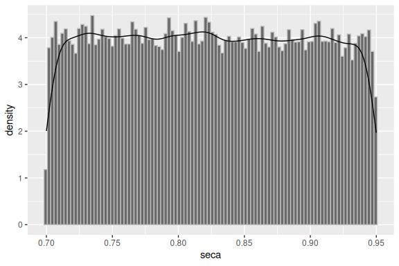

Sensibility prior distribution.

```r
plot(smoke.nd, "seca")
```

Note that a message is provided if the chosen distribution(s) leads to negative cell values, with the number of iterations affected. It is recommended to shift distributions upwards if more than 10% of the iterations are deleted ([Fox et al., 2005](https://doi.org/10.1093/ije/dyi184)).

## Probabilistic Sensitivity Analysis for Uncontrolled Confounding

Let’s illustrate this function with this example where the association between occupational resins exposure and lung cancer mortality is studied, together with the presence of an unmeasured potential confounder, smoking ([Greenland et al., 1994](https://pubmed.ncbi.nlm.nih.gov/7927843/)).

|  | Resins exposed | Resins unexposed |
| --- | --- | --- |
| Cases | 45 | 94 |
| Controls | 257 | 945 |

After adjustment for age and year at death, Greenland et al. found an OR of 1.77 (95% CI from 1.18 to 2.64). Is smoking, for which they had no data about, had an effect on this association? How large the association between resins and smoking had to be to remove the association between resins and lung cancer association after adjustment for smoking? For this, you have to know three bias parameters: the association between smoking and lung cancer, the prevalence of smoking among those unexposed to resins, and the prevalence of smoking in those exposed to resins.

Prior probability distributions are given to each bias parameter. Prevalences of smoking in those exposed to resins, and of smoking in those unexposed to resins receive prior distributions that are uniform between 0.40 and 0.70. Prior distribution for the odds ratio associating smoking with lung cancer mortality is log-normal with 95% limits of 5 and 15. The mean of this distribution is [ln(15) + ln(5)] / 2 = 2.159, and its standard deviation is [ln(15) - ln(5)] / 3.92 = 0.28. It looks like this:

```r
set.seed(123)
x <- rlnorm(10000, meanlog = 2.159, sdlog = 0.28)
quantile(x, c(0.025, 0.975))
```

```
##      2.5%     97.5%
##  4.979672 14.959055
```

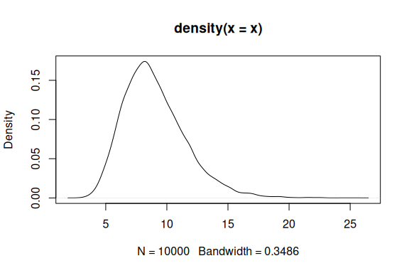

Log-normal distribution with meanlog = 2.159 and sdlog = 0.28.

```r
plot(density(x))
```

Now, let’s run `probsens_conf()` with 50,000 iterations:

```r
set.seed(123)
greenland <- probsens_conf(matrix(c(45, 94, 257, 945),
                                  dimnames = list(c("Cases+", "Cases-"), c("Res+", "Res-")),
                                  nrow = 2, byrow = TRUE),
                           reps = 50000,
                           prev_exp = list("uniform", c(.4, .7)),
                           prev_nexp = list("uniform", c(.4, .7)),
                           risk = list("log-normal", c(2.159, .28)))
```

```
## ℹ Calculating observed measures
```

```
## ⠙ Simple bias analysis
```

```
## ! Samplings lead to 1969 instances in which
## sampled cell counts were zero and discarded.
```

```
## ⠙ Simple bias analysis✔ Simple bias analysis [286ms]
##
## ⠙ Incorporating random error
## ✔ Incorporating random error [77ms]
```

```r
greenland
```

```
##
## ── Observed data ───────────────────────────────────────────────────────────────
## • Outcome: Cases+
## • Comparing: Res+ vs. Res-
```

```
##        Res+ Res-
## Cases+   45   94
## Cases-  257  945
##                                      2.5%    97.5%
## Observed Relative Risk: 1.646999 1.182429 2.294094
##    Observed Odds Ratio: 1.760286 1.202457 2.576898
```

```
## ── Bias-adjusted measures ──
```

```
##                                            Median 2.5th percentile
##            RR (MH) -- systematic error:  1.654391         1.170568
## RR (MH) -- systematic and random error:  1.655420         1.028700
##            OR (SMR) -- systematic error: 1.866437         1.212980
## OR (SMR) -- systematic and random error: 1.870259         1.090092
##                                          97.5th percentile
##            RR (MH) -- systematic error:           2.328447
## RR (MH) -- systematic and random error:           2.652687
##            OR (SMR) -- systematic error:          2.916181
## OR (SMR) -- systematic and random error:          3.248255
```

[figure not shown]

```r
plot(greenland, "rr_tot")
```

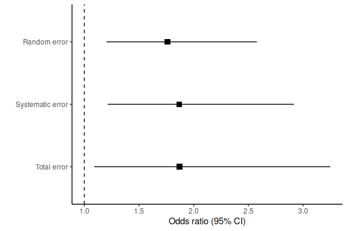

Forest plot of odds ratios.

```r
plot(greenland, "forest_or") + theme_classic()
```